# HW2

author: First Question code and analysis done by omid ghorbani , second question done by Ehsan Mokhtari and Arash Bakhshayee Babaroud

======================================================== ## First Question ## Calculate the interval of equations to compute the performance of the two CSs in Equation 3 and Equation 4 with our classics, i.e. Hoeffding/Chebyshev/Gaussian CIs.

# Implement equations for CSs and CIs

### Equation 4 (Asymptotic CS)

# calculate the interval

###Function to Calculate Confidence Sequences (CSs) and Classical Confidence Intervals (CIs) The function `calculate_intervals` computes CSs and CIs using Equations 3 and 4, along with classical Hoeffding, Chebyshev, and Gaussian CIs.

```r
# Function to calculate Confidence Sequences (CSs) and classical Confidence Intervals (CIs)
calculate_intervals <- function(data, delta, t) {
  # Sample variance
  sample_variance <- var(data)

  # Implement equations for CSs and CIs
  # Equation 3 (CS)
  cs_lower_bound_3 <- (sum(data) / t) - 1.7 * sqrt((log(log(2 * t)) + 0.72 * log(10.4 / delta)) / t)
  cs_upper_bound_3 <- (sum(data) / t) + 1.7 * sqrt((log(log(2 * t)) + 0.72 * log(10.4 / delta)) / t)

  # Equation 4 (Asymptotic CS)
  cs_lower_bound_4 <- (sum(data) / t) - 1.7 * sqrt((log(log(2 * t)) + 0.72 * log(10.4 / delta)) / t) *            sqrt(sample_variance / t)

  cs_upper_bound_4 <- (sum(data) / t )  + 1.7 * sqrt((log(log(2 * t)) + 0.72 * log(10.4 / delta)) / t) *
  sqrt(sample_variance / t)

  # Classical Confidence Intervals
  hoeffding_ci_lower <- mean(data) - sqrt((log(2 / delta)) / (2 * t))
  hoeffding_ci_upper <- mean(data) + sqrt((log(2 / delta)) / (2 * t))

  chebyshev_ci_lower <- mean(data) - sqrt((sample_variance) / (t * delta))
  chebyshev_ci_upper <- mean(data) + sqrt((sample_variance) / (t * delta))

  gaussian_ci_lower <- mean(data) - qnorm(1 - delta / 2) * sqrt(sample_variance / t)
  gaussian_ci_upper <- mean(data) +  qnorm(1 - delta / 2) * sqrt(sample_variance / t)

  result <- list(
    cs_lower_bound_3 = cs_lower_bound_3,
    cs_upper_bound_3 = cs_upper_bound_3,
    cs_lower_bound_4 = cs_lower_bound_4,
    cs_upper_bound_4 = cs_upper_bound_4,
    hoeffding_ci_lower = hoeffding_ci_lower,
    hoeffding_ci_upper = hoeffding_ci_upper,
    chebyshev_ci_lower = chebyshev_ci_lower,
    chebyshev_ci_upper = chebyshev_ci_upper,
    gaussian_ci_lower = gaussian_ci_lower,
    gaussian_ci_upper = gaussian_ci_upper
  )
  return(result)
}

# ... (rest of the code remains the same)
```

# testing with equation 3

###This simulation employs Equation 3 to calculate confidence intervals for varying sample sizes. It then assesses the miscoverage probability and average interval length across simulations, presenting the results through plots for insights into the performance of the confidence sequence

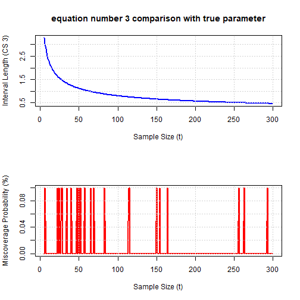

```r
# testing for equation number 3

simulations <- 1000
alpha <- 0.05
t_min <- 5
t_max <- 300

# Initialize results
miscoverage_prob <- matrix(0, nrow = simulations, ncol = t_max - t_min + 1)
interval_length <- matrix(0, nrow = simulations, ncol = t_max - t_min + 1)

# Run simulations
set.seed(123)  # For reproducibility
for (sim in 1:simulations) {
  for (t in t_min:t_max) {
    # Generate data
    data <- rnorm(t, mean = 0)  # Replace with your population distribution

    # Calculate intervals
    intervals <- calculate_intervals(data, alpha, t)

    # Check miscoverage and interval length
    true_mean <- 0
    miscoverage_prob[sim, t - t_min + 1] <- ifelse(true_mean < intervals$cs_lower_bound_3 | true_mean > intervals$cs_upper_bound_3, 1, 0)
    interval_length[sim, t - t_min + 1] <- intervals$cs_upper_bound_3 - intervals$cs_lower_bound_3
  }
}
# Calculate average miscoverage probability and interval length across simulations
avg_miscoverage_prob <- colMeans(miscoverage_prob)
avg_interval_length <- colMeans(interval_length)



# Create a new device with 2 rows and 1 column
t_values <- t_min:t_max
par(mfrow = c(2, 1))
# Plot for Interval Length
plot(t_values, avg_interval_length, type = "l", col = "blue", lwd = 2,
     main = "equation number 3 comparison with true parameter",
     xlab = "Sample Size (t)", ylab = "Interval Length (CS 3)")
grid()

# Plot for Miscoverage Probability
plot(t_values, avg_miscoverage_prob * 100, type = "l", col = "red", lwd = 2,
     xlab = "Sample Size (t)", ylab = "Miscoverage Probability (%)")
grid()
```

```r
# Reset the plotting layout to default
par(mfrow = c(1, 1))
```

# testing with hoefteding inequality

###This simulation employs hoefteding inequality to calculate confidence intervals for varying sample sizes. It then assesses the miscoverage probability and average interval length across simulations, presenting the results through plots for insights into the performance of the confidence sequence

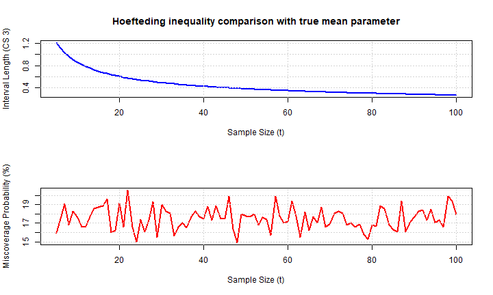

```r
# for testing hoefteding inequality
simulations <- 1000
alpha <- 0.05
t_min <- 5
t_max <- 100
# Initialize results
miscoverage_prob <- matrix(0, nrow = simulations, ncol = t_max - t_min + 1)
interval_length <- matrix(0, nrow = simulations, ncol = t_max - t_min + 1)

# Run simulations
set.seed(123)  # For reproducibility
for (sim in 1:simulations) {
  for (t in t_min:t_max) {
    # Generate data
    data <- rnorm(t, mean = 0)  # Replace with your population distribution

    # Calculate intervals
    intervals <- calculate_intervals(data, alpha, t)

    # Check miscoverage and interval length
    true_mean <- 0
    miscoverage_prob[sim, t - t_min + 1] <- ifelse(true_mean < intervals$hoeffding_ci_lower | true_mean > intervals$hoeffding_ci_upper, 1, 0)
    interval_length[sim, t - t_min + 1] <- intervals$hoeffding_ci_upper - intervals$hoeffding_ci_lower
  }
}

# Calculate average miscoverage probability and interval length across simulations
avg_miscoverage_prob <- colMeans(miscoverage_prob)
avg_interval_length <- colMeans(interval_length)

# Visualize results
t_values <- t_min:t_max

# Create a new device with 2 rows and 1 column
par(mfrow = c(2, 1))

# Plot for Interval Length
plot(t_values, avg_interval_length, type = "l", col = "blue", lwd = 2,
     main = "Hoefteding inequality comparison with true mean parameter",
     xlab = "Sample Size (t)", ylab = "Interval Length (CS 3)")
grid()
# Plot for Miscoverage Probability
plot(t_values, avg_miscoverage_prob * 100, type = "l", col = "red", lwd = 2,
     xlab = "Sample Size (t)", ylab = "Miscoverage Probability (%)")
grid()
```

```r
# Reset the plotting layout to default
par(mfrow = c(1, 1))
```

# testing with chebyshev inequality

###This simulation employs chebyshev inequality to calculate confidence intervals for varying sample sizes. It then assesses the miscoverage probability and average interval length across simulations, presenting the results through plots for insights into the performance of the confidence sequence

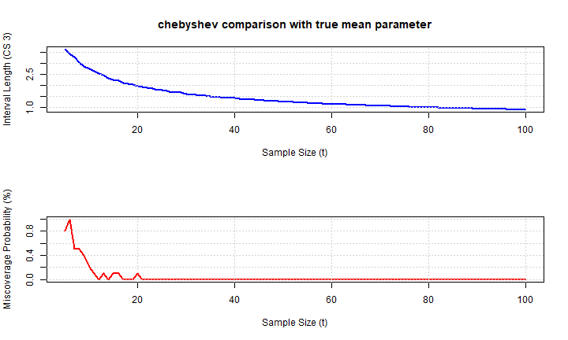

```r
# testing for chebyshev inequality


simulations <- 1000
alpha <- 0.05
t_min <- 5
t_max <- 100

# Initialize results
miscoverage_prob <- matrix(0, nrow = simulations, ncol = t_max - t_min + 1)
interval_length <- matrix(0, nrow = simulations, ncol = t_max - t_min + 1)

# Run simulations
set.seed(123)  # For reproducibility
for (sim in 1:simulations) {
  for (t in t_min:t_max) {
    # Generate data
    data <- rnorm(t, mean = 0)  # Replace with your population distribution

    # Calculate intervals
    intervals <- calculate_intervals(data, alpha, t)

    # Check miscoverage and interval length
    true_mean <- 0
    miscoverage_prob[sim, t - t_min + 1] <- ifelse(true_mean < intervals$chebyshev_ci_lower | true_mean > intervals$chebyshev_ci_upper, 1, 0)
    interval_length[sim, t - t_min + 1] <- intervals$chebyshev_ci_upper - intervals$chebyshev_ci_lower
  }
}

# Calculate average miscoverage probability and interval length across simulations
avg_miscoverage_prob <- colMeans(miscoverage_prob)
avg_interval_length <- colMeans(interval_length)

# Visualize results

t_values <- t_min:t_max
# Create a new device with 2 rows and 1 column
par(mfrow = c(2, 1))

# Plot for Interval Length
plot(t_values, avg_interval_length, type = "l", col = "blue", lwd = 2,
     main = "chebyshev comparison with true mean parameter",
     xlab = "Sample Size (t)", ylab = "Interval Length (CS 3)")
grid()

# Plot for Miscoverage Probability
plot(t_values, avg_miscoverage_prob * 100, type = "l", col = "red", lwd = 2,
     xlab = "Sample Size (t)", ylab = "Miscoverage Probability (%)")
grid()
```

```r
# Reset the plotting layout to default
par(mfrow = c(1, 1))
```

# testing with equation number 4

###This simulation employs equation number 4 to calculate confidence intervals for varying sample sizes. It then assesses the miscoverage probability and average interval length across simulations, presenting the results through plots for insights into the performance of the confidence sequence

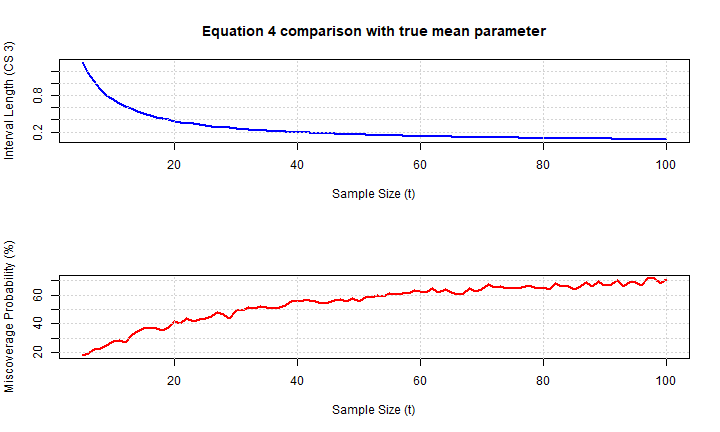

```r
# testing for equation number 4


simulations <- 1000
alpha <- 0.05
t_min <- 5
t_max <- 100

# Initialize results
miscoverage_prob <- matrix(0, nrow = simulations, ncol = t_max - t_min + 1)
interval_length <- matrix(0, nrow = simulations, ncol = t_max - t_min + 1)

# Run simulations
set.seed(123)  # For reproducibility
for (sim in 1:simulations) {
  for (t in t_min:t_max) {
    # Generate data
    data <- rnorm(t, mean = 0)  # Replace with your population distribution

    # Calculate intervals
    intervals <- calculate_intervals(data, alpha, t)

    # Check miscoverage and interval length
    true_mean <- 0
    miscoverage_prob[sim, t - t_min + 1] <- ifelse(true_mean < intervals$cs_lower_bound_4 | true_mean > intervals$cs_upper_bound_4, 1, 0)
    interval_length[sim, t - t_min + 1] <- intervals$cs_upper_bound_4 - intervals$cs_lower_bound_4
  }
}

# Calculate average miscoverage probability and interval length across simulations
avg_miscoverage_prob <- colMeans(miscoverage_prob)
avg_interval_length <- colMeans(interval_length)

# Visualize results

t_values <- t_min:t_max
# Create a new device with 2 rows and 1 column
par(mfrow = c(2, 1))

# Plot for Interval Length
plot(t_values, avg_interval_length, type = "l", col = "blue", lwd = 2,
     main = "Equation 4 comparison with true mean parameter",
     xlab = "Sample Size (t)", ylab = "Interval Length (CS 3)")
grid()

# Plot for Miscoverage Probability
plot(t_values, avg_miscoverage_prob * 100, type = "l", col = "red", lwd = 2,
     xlab = "Sample Size (t)", ylab = "Miscoverage Probability (%)")
grid()
```

```r
# Reset the plotting layout to default
par(mfrow = c(1, 1))
```

# testing with Gaussian Distribution

###This simulation employs Gaussian Dist to calculate confidence intervals for varying sample sizes. It then assesses the miscoverage probability and average interval length across simulations, presenting the results through plots for insights into the performance of the confidence sequence

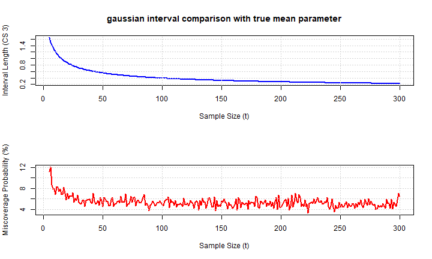

```r
simulations <- 1000
alpha <- 0.05
t_min <- 5
t_max <- 300

# Initialize results
miscoverage_prob <- matrix(0, nrow = simulations, ncol = t_max - t_min + 1)
interval_length <- matrix(0, nrow = simulations, ncol = t_max - t_min + 1)

# Run simulations
set.seed(123)  # For reproducibility
for (sim in 1:simulations) {
  for (t in t_min:t_max) {
    # Generate data
    data <- rnorm(t, mean = 0)  # Replace with your population distribution

    # Calculate intervals
    intervals <- calculate_intervals(data, alpha, t)

    # Check miscoverage and interval length
    true_mean <- 0
    miscoverage_prob[sim, t - t_min + 1] <- ifelse(true_mean < intervals$gaussian_ci_lower | true_mean > intervals$gaussian_ci_upper, 1, 0)
    interval_length[sim, t - t_min + 1] <- intervals$gaussian_ci_upper - intervals$gaussian_ci_lower
  }
}

# Calculate average miscoverage probability and interval length across simulations
avg_miscoverage_prob <- colMeans(miscoverage_prob)
avg_interval_length <- colMeans(interval_length)

# Visualize results

t_values <- t_min:t_max
# Create a new device with 2 rows and 1 column
par(mfrow = c(2, 1))

# Plot for Interval Length
plot(t_values, avg_interval_length, type = "l", col = "blue", lwd = 2,
     main = "gaussian interval comparison with true mean parameter",
     xlab = "Sample Size (t)", ylab = "Interval Length (CS 3)")
grid()

# Plot for Miscoverage Probability
plot(t_values, avg_miscoverage_prob * 100, type = "l", col = "red", lwd = 2,
     xlab = "Sample Size (t)", ylab = "Miscoverage Probability (%)")
grid()
```

```r
# Reset the plotting layout to default
par(mfrow = c(1, 1))
```

# Summary and findings

## Introduction

In all cases, the average length decreases as the sample size increases. However, different inequalities provide insights into the behavior of misconvergence under varying conditions.

## Misconvergence Inequalities

### 1. Hoeffding’s Inequality

- No clear trend observed in misconvergence with an increase in sample size.

### 2. Chebyshev’s Inequality

- Clear trend: Misconvergence decreases as the sample size increases.

### 3. Equation 4

- With an increase in sample size, the probability of misconvergence increases.
- This is due to the relationship with sample variance; as the sample size increases, the variance decreases, leading to smaller confidence intervals and a higher chance of misinterpretation.

### 4. Gaussian Distribution

- Misconvergence decreases with an increase in the number of samples.
- The trend is not as smooth as Chebyshev’s and exhibits some noise.

## Conclusion

Consider the characteristics of each inequality and distribution when analyzing misconvergence trends. Understanding these behaviors is crucial for robust statistical analysis.